# Preprocess ClinVar

Kristoforus

28/07/2019

# Summary

This file transforms the raw ClinVar VCF into a CSV containing domain-level pathogenic and benign mutation counts.

Input: - VCF of raw ClinVar data (downstream_analysis/clinvar_data/clinvar_20190715.vcf) obtained from ftp://ftp.ncbi.nih.gov/pub/clinvar/vcf_GRCh37/archive_2.0/2019/clinvar_20190715.vcf.gz - CSV of the domain-specific coordinate of every unique mutations (downstream_analysis/exac_data/all_mutations_domain_specific.csv) - CSV of ENSG to ENSP one-to-one mapping (downstream_analysis/clinvar_data/ENSG_ENSP_pairings.txt) Output: - CSV of the number of pathogenic and benign mutations for every protein domain (downstream_analysis/clinvar_data/clinvar_reduced.csv)

## Translate genome coordinates of the clinvar variants to protein coordinates

We ran this in parallel using these codes - downstream_analysis/clinvar_data/clinvar_get_prot_coordinate_benign.R - downstream_analysis/clinvar_data/clinvar_get_prot_coordinate_pathogenic.R on this input - downstream_analysis/clinvar_data/clinvar_20190715.vcf to generate - downstream_analysis/clinvar_data/benign_prot_combined.csv - downstream_analysis/clinvar_data/pathogenic_prot_combined.csv

## Populate result df with clinvar annotations

| ENSG | cluster_membership | benign.mut | pathogenic.mut |
| --- | --- | --- | --- |
| ENSG00000000419 | 1 | 4 | 5 |
| ENSG00000000419 | 2 | 2 | 0 |
| ENSG00000001036 | 1 | 0 | 0 |
| ENSG00000001036 | 2 | 0 | 0 |
| ENSG00000001036 | 3 | 0 | 0 |
| ENSG00000001036 | 4 | 0 | 0 |
| ENSG00000001036 | 5 | 0 | 0 |
| ENSG00000001036 | 6 | 0 | 0 |
| ENSG00000001084 | 1 | 0 | 0 |
| ENSG00000001084 | 2 | 0 | 0 |

[output cut: 990 more lines]

## Statistics of the number of ClinVar benign and pathogenic on the domain level

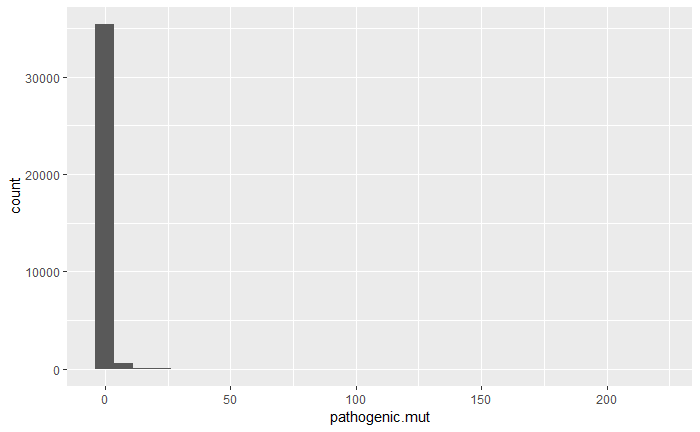

## Statistics of the number of ClinVar benign and pathogenic on the protein level

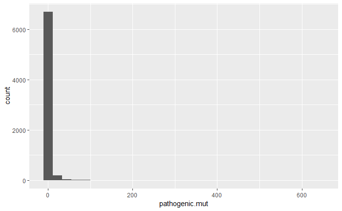